# MA615 Final Project

2018/04/24

## Introduction

- Google Trends Gun Control Toic
- Guns Per 100 Captia by country
- Text Analysis President Obama and Trump Gun Control Public Talk
- Time Series Anaysis US Mass Shooting in the Last 50 Years
- Building Interactive US Mass Shooting Datatable

## Google Trends Analyze Gun Control Topic

Google Trend is a pub web of Google Inc.,base on Google Search that shows how often a particular serach-term is entered relative to the total search-volume across various regions of the world.

The search-term for my project are :

- US Gun Control
- World Gun Control

## Google Trend World Gun Control Popularity

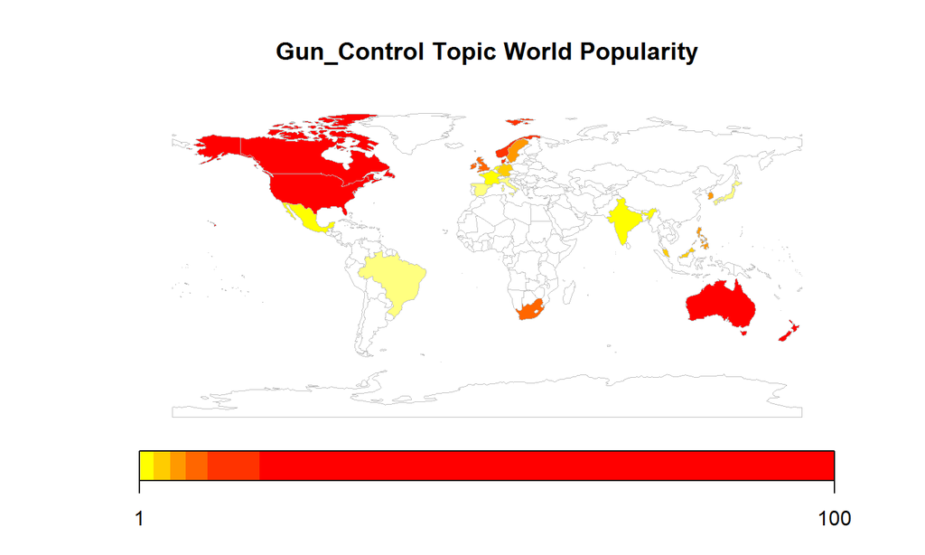

## Google Trend US Gun Control Popularity

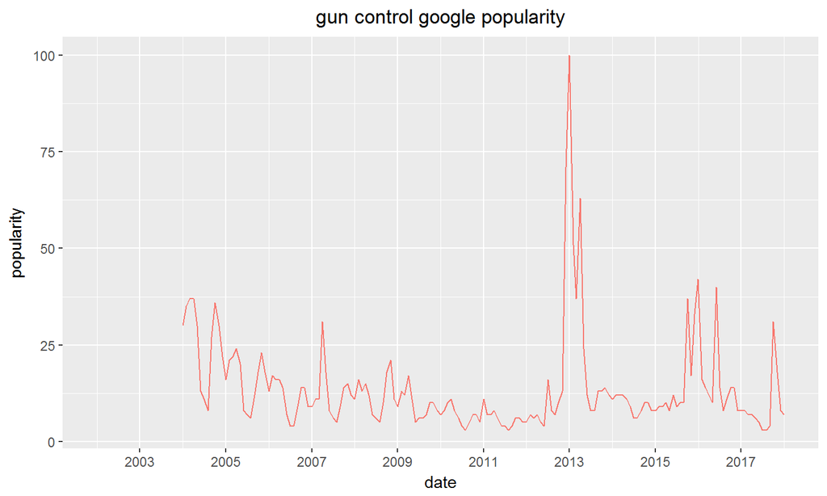

## World Map Guns per 100 Capita

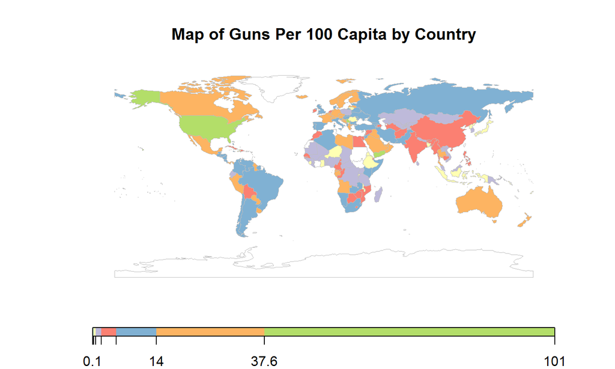

## Text Analysis President Obama Gun Control Public Talk

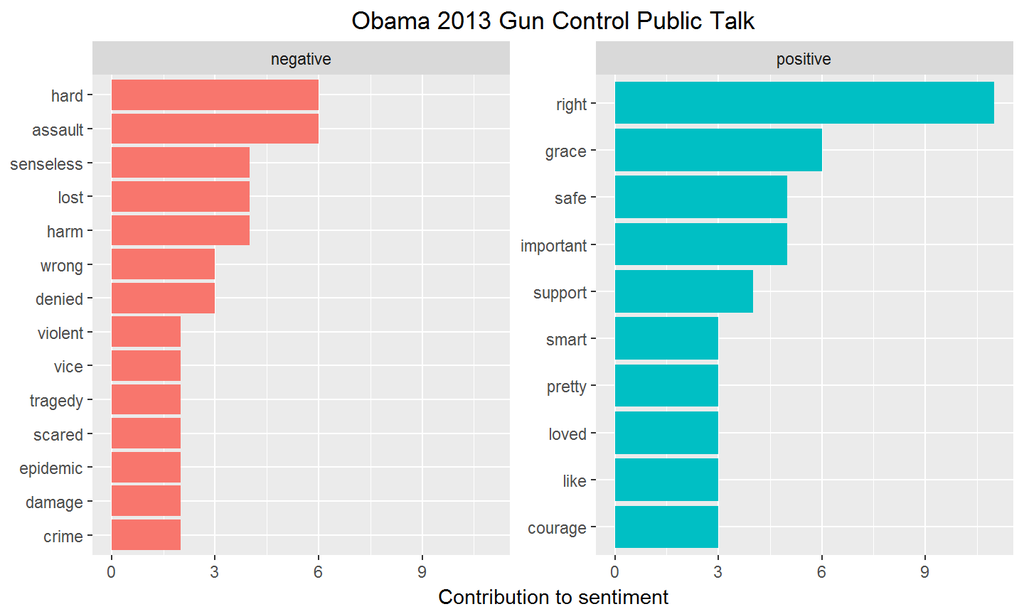

## Text Analysis President Trump Gun Control Public Talk

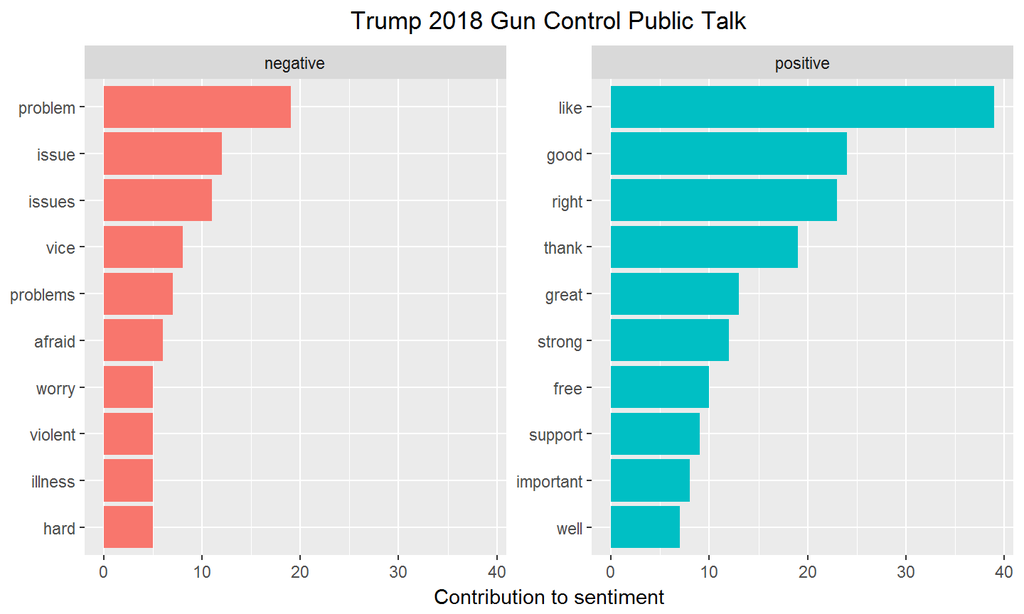

## WordCloud Analysis President Obama Gun Control Public Talk

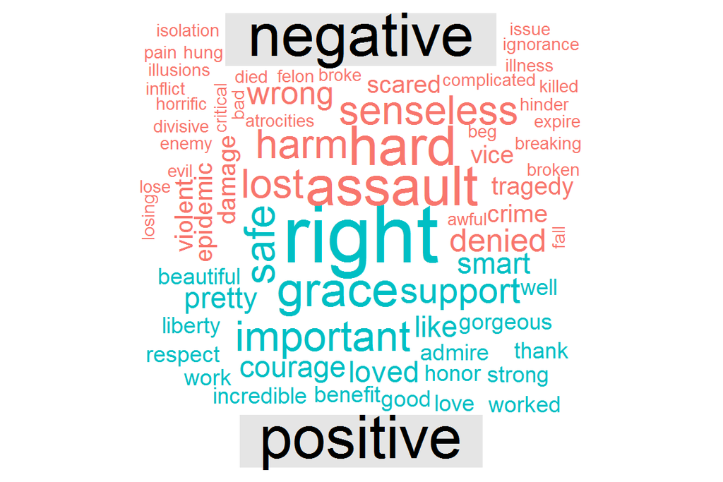

## WordCloud Analysis President Trump Gun Control Public Talk

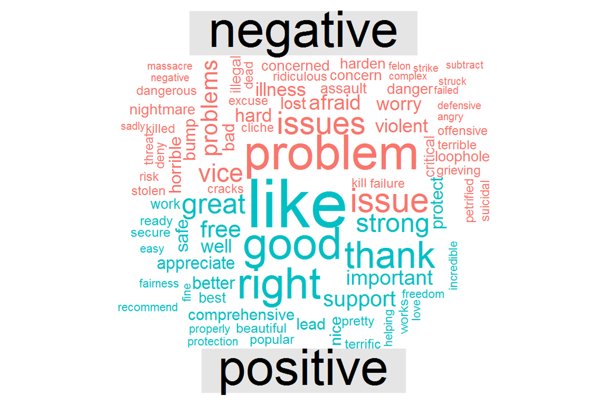

## Word frequency Analysis President Obama Gun Control Public Talk

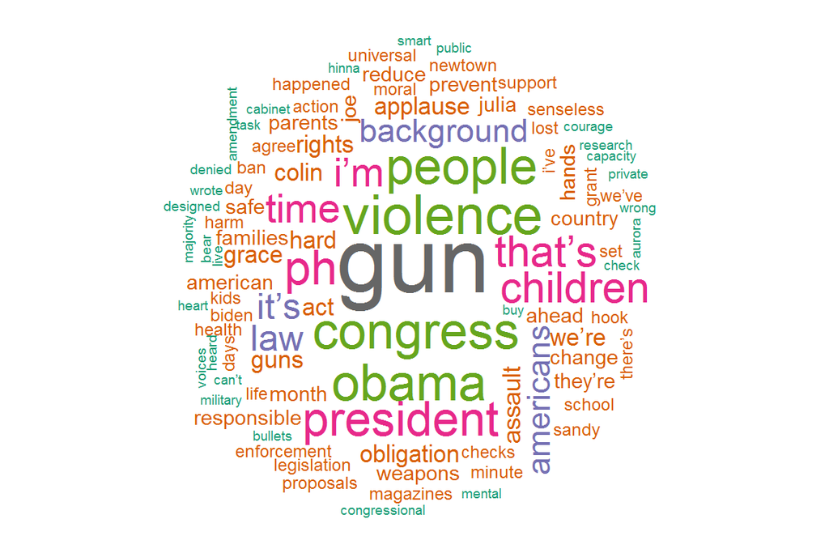

## Word frequency Analysis President Trump Gun Control Public Talk

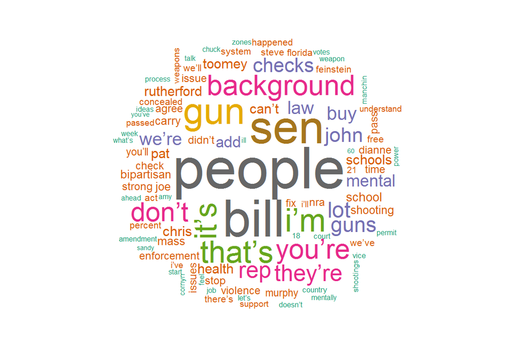

## US Mass Shooting Death/Injured in Past 50 Years

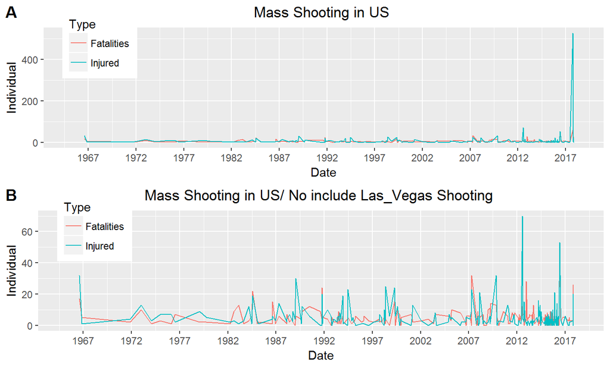

## US Mass Shooting Causes in Past 50 Years

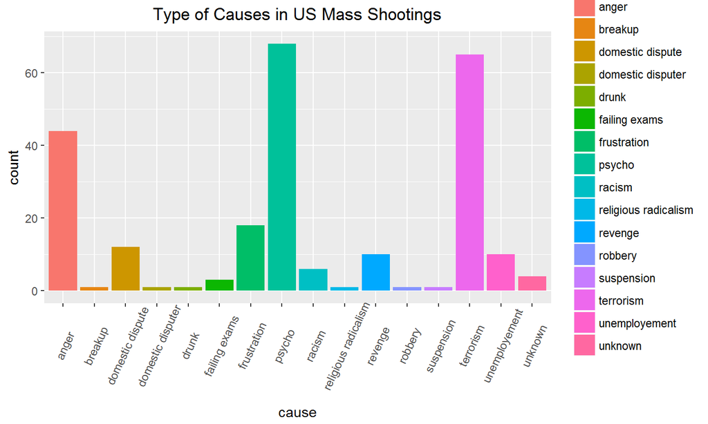

## US Mass Shooting Datatable

Highly recommend to check out this Datatable on my shiny app.[shinyapp](https://jxiao11.shinyapps.io/Shiny_Final/). This table provides a search function and includes all US mass shootings information in past 50 years.

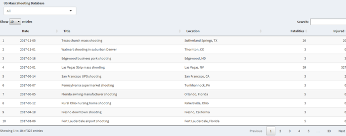

## Discussion

1.Google Trends Gun Control Topic

2.Guns Per 100 Captia by country

- As we can see United States has most gun per 100 capita, and almost double than the second most

## Discussion…

3.Text Analysis President Obama and Trump Gun Control Public Talk

## Discussion…

4.Time Series and Histogram Anaysis US Mass Shooting in the Last 50 Years